# SANJEEV_MT_Project_LearnerNotebook_FullCode__

## **Decision Tree**

#### Tuning Decision Tree ⚛ original

```python
# defining model
tree = DecisionTreeClassifier(random_state=1)

# Parameter grid to pass in RandomSearchCV
param_grid = {'max_depth': np.arange(2,6),
              'min_samples_leaf': [1, 4, 7],
              'max_leaf_nodes' : [10,15],
              'min_impurity_decrease': [0.0001,0.001] }

#Calling RandomizedSearchCV
randomized_cv = RandomizedSearchCV(estimator=tree, param_distributions=param_grid, n_iter=50, n_jobs = -1, scoring=scorer, cv=5, random_state=1)

#Fitting parameters in RandomizedSearchCV
randomized_cv.fit(X_train,y_train)

print("Best parameters are {} with CV score={}:" .format(randomized_cv.best_params_,randomized_cv.best_score_))
```

```
Best parameters are {'min_samples_leaf': 7, 'min_impurity_decrease': 0.0001, 'max_leaf_nodes': 15, 'max_depth': 5} with CV score=0.4956230605912134:
```

#### Tuning Decision Tree ⚛ oversampled

```python
# defining model
tree_over = DecisionTreeClassifier(random_state=1)

# Parameter grid to pass in RandomSearchCV
param_grid = {'max_depth': np.arange(2,6),
              'min_samples_leaf': [1, 4, 7],
              'max_leaf_nodes' : [10,15],
              'min_impurity_decrease': [0.0001,0.001] }

#Calling RandomizedSearchCV
randomized_cv = RandomizedSearchCV(estimator=tree_over, param_distributions=param_grid, n_iter=50, n_jobs = -1, scoring=scorer, cv=5, random_state=1)

#Fitting parameters in RandomizedSearchCV
randomized_cv.fit(X_train_over,y_train_over)

print("Best parameters are {} with CV score={}:" .format(randomized_cv.best_params_,randomized_cv.best_score_))
```

```
Best parameters are {'min_samples_leaf': 7, 'min_impurity_decrease': 0.001, 'max_leaf_nodes': 15, 'max_depth': 3} with CV score=0.8740479375486185:
```

#### Tuning Decision Tree ⚛ undersampled

```python
# defining model
tree_under = DecisionTreeClassifier(random_state=1)

# Parameter grid to pass in RandomSearchCV
param_grid = {'max_depth': np.arange(2,20),
              'min_samples_leaf': [1, 2, 5, 7],
              'max_leaf_nodes' : [5, 10,15],
              'min_impurity_decrease': [0.0001,0.001] }

#Calling RandomizedSearchCV
randomized_cv = RandomizedSearchCV(estimator=tree_under, param_distributions=param_grid, n_iter=50, n_jobs = -1, scoring=scorer, cv=5, random_state=1)

#Fitting parameters in RandomizedSearchCV
randomized_cv.fit(X_train_un,y_train_un)

print("Best parameters are {} with CV score={}:" .format(randomized_cv.best_params_,randomized_cv.best_score_))
```

```
Best parameters are {'min_samples_leaf': 7, 'min_impurity_decrease': 0.001, 'max_leaf_nodes': 15, 'max_depth': 6} with CV score=0.809186673199412:
```

## Logistic Regression ▶

#### Tuning Logistic regression ⚛ original

```python
 # defining model
logistic = LogisticRegression(random_state=1)

#Parameter grid to pass in RandomSearchCV
param_grid = {'C': np.arange(0.1,1.1,0.1)}

#Calling RandomizedSearchCV
randomized_cv = RandomizedSearchCV(estimator=logistic, param_distributions=param_grid, scoring=scorer, n_iter=50, n_jobs = -1, cv=5, random_state=1)

#Fitting parameters in RandomizedSearchCV
randomized_cv.fit(X_train, y_train)

print("Best parameters are {} with CV score={}:" .format(randomized_cv.best_params_,randomized_cv.best_score_))
```

```
Best parameters are {'C': 0.2} with CV score=0.5044667646578475:
```

#### Tuning Logistic regression ⚛ oversampled

```python
 # defining model
logistic_over = LogisticRegression(random_state=1)

#Parameter grid to pass in RandomSearchCV
param_grid = {'C': np.arange(0.1,1.1,0.1)}

#Calling RandomizedSearchCV
randomized_cv = RandomizedSearchCV(estimator=logistic_over, param_distributions=param_grid, scoring=scorer, n_iter=50, n_jobs = -1, cv=5, random_state=1)

#Fitting parameters in RandomizedSearchCV
randomized_cv.fit(X_train_over, y_train_over)

print("Best parameters are {} with CV score={}:" .format(randomized_cv.best_params_,randomized_cv.best_score_))
```

```
Best parameters are {'C': 0.1} with CV score=0.87941624122865:
```

#### Tuning Logistic regression ⚛ under sampled

```python
 # defining model
logistic_under = LogisticRegression(random_state=1)

#Parameter grid to pass in RandomSearchCV
param_grid = {'C': np.arange(0.1,1.1,0.1)}

#Calling RandomizedSearchCV
randomized_cv = RandomizedSearchCV(estimator=logistic_under, param_distributions=param_grid, scoring=scorer, n_iter=50, n_jobs = -1, cv=5, random_state=1)

#Fitting parameters in RandomizedSearchCV
randomized_cv.fit(X_train_un, y_train_un)

print("Best parameters are {} with CV score={}:" .format(randomized_cv.best_params_,randomized_cv.best_score_))
```

```
Best parameters are {'C': 0.1} with CV score=0.8488567695574065:
```

### Sample Parameter Grids

**Hyperparameter tuning can take a long time to run, so to avoid that time complexity - you can use the following grids, wherever required.**

- For Gradient Boosting:

param_grid = { "n_estimators": np.arange(100,150,25), "learning_rate": [0.2, 0.05, 1], "subsample":[0.5,0.7], "max_features":[0.5,0.7] }

- For Adaboost:

param_grid = { "n_estimators": [100, 150, 200], "learning_rate": [0.2, 0.05], "base_estimator": [DecisionTreeClassifier(max_depth=1, random_state=1), DecisionTreeClassifier(max_depth=2, random_state=1), DecisionTreeClassifier(max_depth=3, random_state=1), ] }

- For Bagging Classifier:

param_grid = { 'max_samples': [0.8,0.9,1], 'max_features': [0.7,0.8,0.9], 'n_estimators' : [30,50,70], }

- For Random Forest:

param_grid = { "n_estimators": [200,250,300], "min_samples_leaf": np.arange(1, 4), "max_features": [np.arange(0.3, 0.6, 0.1),'sqrt'], "max_samples": np.arange(0.4, 0.7, 0.1) }

- For Decision Trees:

param_grid = { 'max_depth': np.arange(2,6), 'min_samples_leaf': [1, 4, 7], 'max_leaf_nodes' : [10, 15], 'min_impurity_decrease': [0.0001,0.001] }

- For Logistic Regression:

param_grid = {'C': np.arange(0.1,1.1,0.1)}

- For XGBoost:

param_grid={ 'n_estimators': [150, 200, 250], 'scale_pos_weight': [5,10], 'learning_rate': [0.1,0.2], 'gamma': [0,3,5], 'subsample': [0.8,0.9] }

**Checking all models cv_score**

#### Gradient boosting

- original data=0.76
- **oversampled data=0.97**
- Undersampled data=0.89

#### Adaboost

- Original data=0.74
- **Oversampled data=0.94**
- Undersampled data=0.87

#### Logistic Regression

- Original data=0.50
- **Oversampled data=0.88**
- Undersampled data=0.84

**Oversampled data cv score is high compare to undersampled data**

**Note: further we will go with oversampled data**

## Performance checking (also for pipeline)

**Xg boosting**

```python
#pipeline: extreme gradient boost
xgb_tuned=XGBClassifier(subsample= 0.9, scale_pos_weight= 5, reg_lambda= 10, n_estimators=50, max_depth= 3, learning_rate= 0.01, gamma= 3
)
xgb_tuned.fit(X_train_over, y_train_over)
```

```
XGBClassifier(base_score=None, booster=None, callbacks=None,
              colsample_bylevel=None, colsample_bynode=None,
              colsample_bytree=None, device=None, early_stopping_rounds=None,
              enable_categorical=False, eval_metric=None, feature_types=None,
              gamma=3, grow_policy=None, importance_type=None,
              interaction_constraints=None, learning_rate=0.01, max_bin=None,
              max_cat_threshold=None, max_cat_to_onehot=None,
              max_delta_step=None, max_depth=3, max_leaves=None,
              min_child_weight=None, missing=nan, monotone_constraints=None,
              multi_strategy=None, n_estimators=50, n_jobs=None,
              num_parallel_tree=None, random_state=None, ...)
```

```python
#checking performance
xgb_train_perf = model_performance_classification_sklearn(xgb_tuned, X_train_over, y_train_over)
xgb_val_perf = model_performance_classification_sklearn(xgb_tuned, X_val, y_val)

# Print performance metrics
print("This is the training performance on the oversampled dataset:","\n", xgb_train_perf)
print("This is the validation performance on the original validation set:","\n", xgb_val_perf)
```

```
This is the training performance on the oversampled dataset:
    Accuracy  Recall  Precision    F1
0     0.500   1.000      0.500 0.667
This is the validation performance on the original validation set:
    Accuracy  Recall  Precision    F1
0     0.055   1.000      0.055 0.104
```

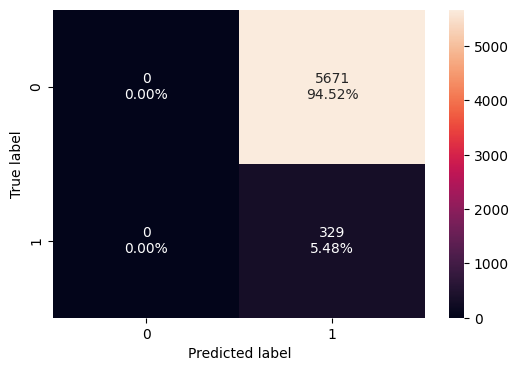

```python
# creating confusion matrix
confusion_matrix_sklearn(xgb_tuned, X_val, y_val)
```

**Gradient boosting**

```python
 # gradient boosting: Createing new pipeline with best parameters
gbm_tuned = GradientBoostingClassifier(
    subsample=0.7,
    n_estimators=125,
    max_features=0.5,
    learning_rate=1
)

gbm_tuned.fit(X_train_over, y_train_over)
```

```
GradientBoostingClassifier(learning_rate=1, max_features=0.5, n_estimators=125,
                           subsample=0.7)
```

```python
# Check performance on oversampled train set
gbm_train_perf = model_performance_classification_sklearn(gbm_tuned, X_train_over, y_train_over)
gbm_val_perf = model_performance_classification_sklearn(gbm_tuned, X_val, y_val)

# Print performance metrics
print("This is the training performance on the oversampled dataset:","\n", gbm_train_perf)
print("This is the validation performance on the original validation set:","\n", gbm_val_perf)
```

```
This is the training performance on the oversampled dataset:
    Accuracy  Recall  Precision    F1
0     0.995   0.994      0.995 0.995
This is the validation performance on the original validation set:
    Accuracy  Recall  Precision    F1
0     0.966   0.842      0.646 0.731
```

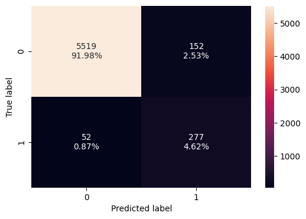

```python
# creating confusion matrix
confusion_matrix_sklearn(gbm_tuned, X_val, y_val)
```

**Random forest**

```python
 # RANDOM FOREST: Create new pipeline with best parameters
rf_tuned = RandomForestClassifier(
    max_features='sqrt',           # Limit the number of features considered for each split
    random_state=1,             # Set a random state for reproducibility
    max_samples=0.6,            # Reduce the number of samples used to train each tree
    n_estimators=350,           # Decrease the number of trees in the forest
    min_samples_leaf=1          # Decrease the minimum number of samples required to be at a leaf node
)

rf_tuned.fit(X_train_over, y_train_over)
```

```
RandomForestClassifier(max_samples=0.6, n_estimators=350, random_state=1)
```

```python
 # Check performance on oversampled train set
rf_train_perf = model_performance_classification_sklearn(rf_tuned, X_train_over, y_train_over)
# Check performance on validation set
rf_val_perf = model_performance_classification_sklearn(rf_tuned, X_val, y_val)
# Print performance metrics
print("This is the training performance on the oversampled dataset:","\n", rf_train_perf)
print("This is the validation performance on the original validation set:","\n", rf_val_perf)
```

```
This is the training performance on the oversampled dataset:
    Accuracy  Recall  Precision    F1
0     1.000   0.999      1.000 1.000
This is the validation performance on the original validation set:
    Accuracy  Recall  Precision    F1
0     0.991   0.863      0.963 0.910
```

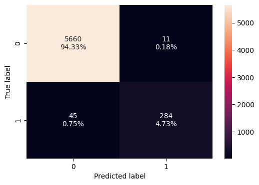

```python
# creating confusion matrix
confusion_matrix_sklearn(rf_tuned, X_val, y_val)
```

**Adaboost**

```python
# adda boost
ada_tuned = AdaBoostClassifier(
    n_estimators=200,
    learning_rate=0.2,
    base_estimator=DecisionTreeClassifier(max_depth=2, random_state=42))

ada_tuned.fit(X_train_over, y_train_over)
```

```
AdaBoostClassifier(base_estimator=DecisionTreeClassifier(max_depth=2,
                                                         random_state=42),
                   learning_rate=0.2, n_estimators=200)
```

```python
 # Check performance on oversampled train set
ada_train_perf = model_performance_classification_sklearn(ada_tuned, X_train_over, y_train_over)
 # Check performance on validation set
ada_val_perf = model_performance_classification_sklearn(ada_tuned, X_val, y_val)
# Print performance metrics
print("This is the training performance on the oversampled dataset:","\n", ada_train_perf )
print("This is the validation performance on the original validation set:","\n", ada_val_perf )
```

[output not shown]

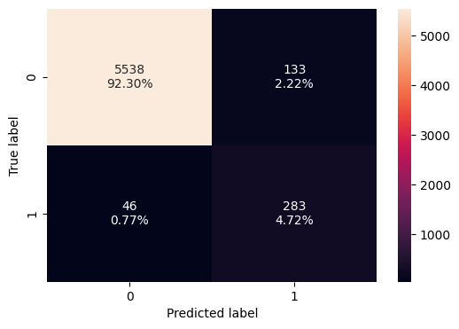

```python
# creating confusion matrix
confusion_matrix_sklearn(ada_tuned, X_val, y_val)
```

**Decision Tree**

```python
 # DECISION TREE: Create new pipeline with best parameters
dtree_tuned = DecisionTreeClassifier(
    min_samples_leaf=7,
    min_impurity_decrease=0.001,
    max_leaf_nodes=15,
    max_depth=3)


dtree_tuned.fit(X_train_over, y_train_over)
```

```
DecisionTreeClassifier(max_depth=3, max_leaf_nodes=15,
                       min_impurity_decrease=0.001, min_samples_leaf=7)
```

```python
 # Check performance on oversampled train set
dtree_train_perf = model_performance_classification_sklearn(dtree_tuned, X_train_over, y_train_over)
dtree_val_perf = model_performance_classification_sklearn(dtree_tuned, X_val, y_val)
# Print performance metrics
print("This is the training performance on the oversampled dataset:","\n", dtree_train_perf )
print("This is the validation performance on the original validation set:","\n", dtree_val_perf )
```

```
This is the training performance on the oversampled dataset:
    Accuracy  Recall  Precision    F1
0     0.866   0.871      0.861 0.866
This is the validation performance on the original validation set:
    Accuracy  Recall  Precision    F1
0     0.841   0.818      0.231 0.361
```

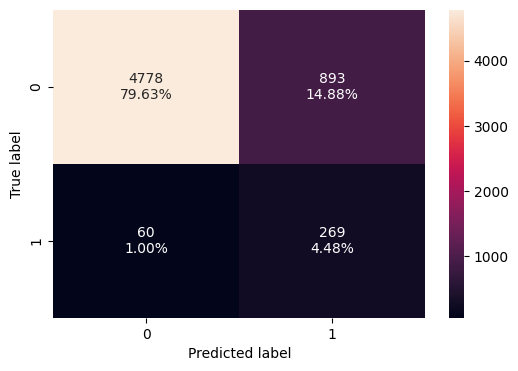

```python
# creating confusion matrix
confusion_matrix_sklearn(dtree_tuned, X_val, y_val)
```

**Logistic Regression**

```python
 # LOGISTIC REGRESSION: Create new pipeline with best parameters

log_tuned = LogisticRegression(C = 0.1)

log_tuned.fit(X_train_over, y_train_over)
```

```
LogisticRegression(C=0.1)
```

```python
# check performance on training set
log_train_perf = model_performance_classification_sklearn(log_tuned, X_train_over, y_train_over)
  # Check performance on validation set
log_val_perf = model_performance_classification_sklearn(log_tuned, X_val, y_val)
# Print performance metrics
print("This is the training performance on the oversampled dataset:","\n", log_train_perf )
print("This is the validation performance on the original validation set:","\n", log_val_perf )
```

```
This is the training performance on the oversampled dataset:
    Accuracy  Recall  Precision    F1
0     0.880   0.880      0.880 0.880
This is the validation performance on the original validation set:
    Accuracy  Recall  Precision    F1
0     0.879   0.836      0.290 0.431
```

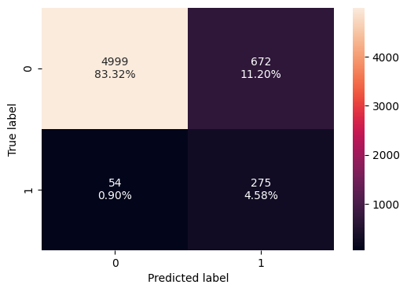

```python
# creating confusion matrix
confusion_matrix_sklearn(log_tuned, X_val, y_val)
```

## Model performance comparison and choosing the final model

```python
 # training performance comparison

models_train_comp_df = pd.concat(
    [
        xgb_train_perf.T,
        dtree_train_perf.T,
        rf_train_perf.T,
        gbm_train_perf.T,
        ada_train_perf.T,
        log_train_perf.T
    ],
    axis=1,
)

models_train_comp_df.columns = [
    "XGB tuned with oversampled data",
    "Decision Tree tuned with oversampled data",
    "Random forest tuned with oversampled data",
    "Gradient Boosting tuned with oversampled data",
    "AdaBoost classifier tuned with oversampled data",
    "Logistic Regression tuned with oversampled data",
]
print("Training performance comparison:")
models_train_comp_df.style.set_properties(**{'background-color': 'yellow', 'color': 'darkblue','border-color': 'blue','border-width': '8px','border-style': 'solid',})
```

```
Training performance comparison:
```

|  | XGB tuned with oversampled data | Decision Tree tuned with oversampled data | Random forest tuned with oversampled data | Gradient Boosting tuned with oversampled data | AdaBoost classifier tuned with oversampled data | Logistic Regression tuned with oversampled data |
| --- | --- | --- | --- | --- | --- | --- |
| Accuracy | 0.500000 | 0.865610 | 0.999660 | 0.994894 | 0.965012 | 0.880059 |
| Recall | 1.000000 | 0.871473 | 0.999470 | 0.994402 | 0.946895 | 0.879567 |
| Precision | 0.500000 | 0.861373 | 0.999849 | 0.995381 | 0.982496 | 0.880433 |
| F1 | 0.666667 | 0.866393 | 0.999660 | 0.994891 | 0.964367 | 0.880000 |

```python
 # validation performance comparison

models_val_comp_df = pd.concat(
    [
        xgb_val_perf.T,
        dtree_val_perf.T,
        rf_val_perf.T,
        gbm_val_perf.T,
        ada_val_perf.T,
        log_val_perf.T
    ],
    axis=1,
)

models_val_comp_df.columns = [
    "XGB tuned with oversampled data",
    "Decision Tree tuned with oversampled data",
    "Random forest tuned with oversampled data",
    "Gradient Boosting tuned with oversampled data",
    "AdaBoost classifier tuned with oversampled data",
    "Logistic Regression tuned with oversampled data",
]
print("Validation performance comparison:")
models_val_comp_df.style.set_properties(**{'background-color': 'yellow', 'color': 'darkblue','border-color': 'blue','border-width': '8px','border-style': 'solid',})
```

```
Validation performance comparison:
```

|  | XGB tuned with oversampled data | Decision Tree tuned with oversampled data | Random forest tuned with oversampled data | Gradient Boosting tuned with oversampled data | AdaBoost classifier tuned with oversampled data | Logistic Regression tuned with oversampled data |
| --- | --- | --- | --- | --- | --- | --- |
| Accuracy | 0.054833 | 0.841167 | 0.990667 | 0.966000 | 0.970167 | 0.879000 |
| Recall | 1.000000 | 0.817629 | 0.863222 | 0.841945 | 0.860182 | 0.835866 |
| Precision | 0.054833 | 0.231497 | 0.962712 | 0.645688 | 0.680288 | 0.290391 |
| F1 | 0.103966 | 0.360832 | 0.910256 | 0.730871 | 0.759732 | 0.431034 |

```python
# Calculating different metrics on the test set
ada_grid_test = model_performance_classification_sklearn(ada_tuned, X_test, y_test)
print("Test performance:")
ada_grid_test
```

```
Test performance:
```

|  | Accuracy | Recall | Precision | F1 |
| --- | --- | --- | --- | --- |
| 0 | 0.968 | 0.844 | 0.669 | 0.746 |

- The performance on test data is generalised
- Let's check the important features for prediction as per the the final model

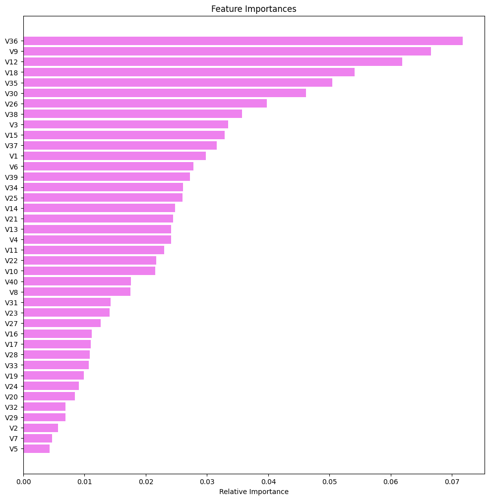

```python
 # Important features of the final model

feature_names = X_train.columns
importances = ada_tuned.feature_importances_
indices = np.argsort(importances)

plt.figure(figsize=(12,12))
plt.title('Feature Importances')
plt.barh(range(len(indices)), importances[indices], color='violet', align='center')
 plt.yticks(range(len(indices)), [feature_names[i] for i in indices])
plt.xlabel('Relative Importance')
plt.show()
```

#### Observations:

- V36 is Most important feature.
- V9,V12,V18,V35 is important feature.

**Lets create pipeline**

## Pipelines to build the final model

Now that we have a final model, let's use pipelines to put the model into production. We know that we can use pipelines to standardize the model building, but the steps in a pipeline are applied to each and every variable.

How can we personalize the pipeline to perform different preprocessing steps on different columns? - **By using Column Transformer**

**Column Transformer**

- Column Transformer allows different columns or column subsets of the input to be transformed separately and the features generated by each transformer will be concatenated to form a single feature space
- This is useful for heterogeneous or columnar data to combine several feature extraction mechanisms or transformations into a single transformer

**Note**: We will be doing missing value imputation for the whole data so that if there are any missing values in the data in future, they can be taken care of

```python
# Define features and target variable
features = ['V1', 'V2', 'V3', 'V4', 'V5', 'V6', 'V7', 'V8', 'V9', 'V10', 'V11',
            'V12', 'V13', 'V14', 'V15', 'V16', 'V17', 'V18', 'V19', 'V20', 'V21',
            'V22', 'V23', 'V24', 'V25', 'V26', 'V27', 'V28', 'V29', 'V30', 'V31',
            'V32', 'V33', 'V34', 'V35', 'V36', 'V37', 'V38', 'V39', 'V40']
target = 'Target'

# Create transformer for numerical variables
numerical_transformer = Pipeline(steps=[
    ("imputer", SimpleImputer(strategy="median"))
])

# Create column transformer for preprocessing
preprocessor = ColumnTransformer(
    transformers=[
        ("numerical", numerical_transformer, features),
    ],
    remainder="passthrough"
)

# Split the data into train and test sets
X_train, X_test, y_train, y_test = train_test_split(
    df_1[features], df_1[target], test_size=0.30, random_state=1, stratify=df_1[target]
)

# Create a new pipeline with specified parameters
model = Pipeline(
    steps=[
        ("pre", preprocessor),  # Preprocessing steps
        ("Adaboost", AdaBoostClassifier(
                                         n_estimators=200,
                                         learning_rate=0.2,
                                         base_estimator=DecisionTreeClassifier(max_depth=2, random_state=1)))
    ]
)

# Fit the model on training data
model.fit(X_train, y_train)
```

```
Pipeline(steps=[('pre',
                 ColumnTransformer(remainder='passthrough',
                                   transformers=[('numerical',
                                                  Pipeline(steps=[('imputer',
                                                                   SimpleImputer(strategy='median'))]),
                                                  ['V1', 'V2', 'V3', 'V4', 'V5',
                                                   'V6', 'V7', 'V8', 'V9',
                                                   'V10', 'V11', 'V12', 'V13',
                                                   'V14', 'V15', 'V16', 'V17',
                                                   'V18', 'V19', 'V20', 'V21',
                                                   'V22', 'V23', 'V24', 'V25',
                                                   'V26', 'V27', 'V28', 'V29',
                                                   'V30', ...])])),
                ('Adaboost',
                 AdaBoostClassifier(base_estimator=DecisionTreeClassifier(max_depth=2,
                                                                          random_state=1),
                                    learning_rate=0.2, n_estimators=200))])
```

### Test set final performance

```python
# Let's check the performance on test set
Model_test = model_performance_classification_sklearn(model, X_test, y_test)
Model_test
```

|  | Accuracy | Recall | Precision | F1 |
| --- | --- | --- | --- | --- |
| 0 | 0.985 | 0.763 | 0.958 | 0.849 |

- we get accuracy - 0.985, recall-0.763, precision-0.958, f1-0.849.

# Business Insights and Conclusions